# Plankton Recognition

#### Group 11: Yazid Mouline & Guillaume Requena | AML Class 2020

```python
from google.colab import drive
import numpy as np
import matplotlib.pyplot as plt
import pandas as pd
import seaborn as sns
from time import time

from skimage.transform import resize
import scipy.ndimage
from random import randint
from skimage import color
import itertools

from sklearn.model_selection import train_test_split
from keras.applications.vgg16 import VGG16
from keras.models import Model
from keras.models import Sequential
import keras
import keras.backend as K
from keras.callbacks import ModelCheckpoint
from keras.preprocessing.image import ImageDataGenerator

from keras.layers import Activation
from keras.layers import Dropout
from keras.layers import Flatten
from keras.layers import Dense
from keras.layers import Conv2D
from keras.layers import MaxPooling2D

from sklearn.metrics import f1_score
from sklearn.metrics import roc_curve, auc

import zipfile
from io import BytesIO
from PIL import Image
```

### Data importation

```python
drive.mount('/content/drive/',force_remount=True)
```

```
Go to this URL in a browser: https://accounts.google.com/o/oauth2/auth?client_id=947318989803-6bn6qk8qdgf4n4g3pfee6491hc0brc4i.apps.googleusercontent.com&redirect_uri=urn%3aietf%3awg%3aoauth%3a2.0%3aoob&response_type=code&scope=email%20https%3a%2f%2fwww.googleapis.com%2fauth%2fdocs.test%20https%3a%2…

Enter your authorization code:
··········
```

```python
def extract_zip_to_memory(input_zip):
    '''
    This function extracts the images stored inside the given zip file.
    It stores the result in a python dictionary.

    input_zip (string): path to the zip file

    returns (dict): {filename (string): image_file (bytes)}
    '''
    input_zip=zipfile.ZipFile(input_zip)
    return {name: BytesIO(input_zip.read(name)) for name in input_zip.namelist() if name.endswith('.jpg')}

# Load the image as a numpy array:
# np_arr = np.array(Image.open(img_files['imgs/32738710.jpg']))

# Be aware that the dictionary will occupy roughly 2GB of computer memory!
# To free this memory again, run:
# del img_files
```

```python
img_files = extract_zip_to_memory('/content/drive/My Drive/AML/Chal2 - Plankton/Data/imgs.zip')
```

### Data exploration: analyzing metadata

```python
meta = pd.read_csv('/content/drive/My Drive/AML/Chal2 - Plankton/Data/meta.csv')
taxo = pd.read_csv('/content/drive/My Drive/AML/Chal2 - Plankton/Data/taxo.csv')
```

```python
listtaxo = np.array(taxo['levelName'])
for word in listtaxo:
    print(word)
```

```
#
¦--living
¦   ¦--Bacteria
¦   ¦   °--Cyanobacteria
¦   ¦       °--Cyanophyceae
¦   ¦           °--Trichodesmium
¦   ¦--Eukaryota
¦   ¦   ¦--Harosa
¦   ¦   ¦   ¦--Alveolata
¦   ¦   ¦   ¦   ¦--Ciliophora
¦   ¦   ¦   ¦   ¦   °--Intramacronucleata
¦   ¦   ¦   ¦   ¦       ¦--Oligohymenophorea
¦   ¦   ¦   ¦   ¦       ¦   °--Peritrichia
¦   ¦   ¦   ¦   ¦       ¦       °--Zoothamniidae
¦   ¦   ¦   ¦   ¦       ¦--Prostomatea
¦   ¦   ¦   ¦   ¦       ¦   °--Prostomatea X
¦   ¦   ¦   ¦   ¦       ¦       °--Colepidae
¦   ¦   ¦   ¦   ¦       ¦           °--Tiarina
¦   ¦   ¦   ¦   ¦       ¦               °--Tiarina fusus
¦   ¦   ¦   ¦   ¦       °--Spirotrichea
¦   ¦   ¦   ¦   ¦           °--Choreotrichia
¦   ¦   ¦   ¦   ¦               ¦--Cyttarocylididae
¦   ¦   ¦   ¦   ¦               ¦   °--Cyttarocylis
¦   ¦   ¦   ¦   ¦               ¦--Dictyocystidae
¦   ¦   ¦   ¦   ¦               ¦   ¦--Codonaria
¦   ¦   ¦   ¦   ¦               ¦   ¦--Codonellopsis
¦   ¦   ¦   ¦   ¦               ¦   °--Dictyocysta
¦   ¦   ¦   ¦   ¦               ¦--Rhabdonellidae
¦   ¦   ¦   ¦   ¦               ¦   °--Rhabdonella
¦   ¦   ¦   ¦   ¦               ¦--Stenosemellidae
¦   ¦   ¦   ¦   ¦               ¦   °--Stenosemella
¦   ¦   ¦   ¦   ¦               ¦--Tintinnidiidae
¦   ¦   ¦   ¦   ¦               ¦   ¦--Amphorellopsis
¦   ¦   ¦   ¦   ¦               ¦   ¦--Eutintinnus
¦   ¦   ¦   ¦   ¦               ¦   ¦--Salpingella
¦   ¦   ¦   ¦   ¦               ¦   °--Steenstrupiella
¦   ¦   ¦   ¦   ¦               ¦--Undellidae
¦   ¦   ¦   ¦   ¦               °--Xystonellidae
¦   ¦   ¦   ¦   ¦                   ¦--Dadayiella
¦   ¦   ¦   ¦   ¦                   ¦   °--Dadayiella ganymedes
```

[output cut: 123 more lines]

```
¦   ¦--artefact
¦   ¦   °--badfocus
¦   ¦--detritus
¦   ¦--feces
¦   °--plastic
¦       °--other
¦           ¦--pollen
¦           ¦--rods
¦           °--silks
°--temporary
¦--t001
¦--t002
¦--t004
¦--t007
°--t010
```

```python
meta.info()
```

```
<class 'pandas.core.frame.DataFrame'>
RangeIndex: 243610 entries, 0 to 243609
Data columns (total 14 columns):
 #   Column       Non-Null Count   Dtype
---  ------       --------------   -----
 0   objid        243610 non-null  float64
 1   projid       243610 non-null  int64
 2   id           243610 non-null  int64
 3   status       243610 non-null  object
 4   latitude     243610 non-null  float64
 5   longitude    243610 non-null  float64
 6   objdate      243610 non-null  object
 7   objtime      243610 non-null  object
 8   depth_min    243610 non-null  int64
 9   depth_max    243610 non-null  int64
 10  unique_name  243610 non-null  object
 11  lineage      243610 non-null  object
 12  level1       240276 non-null  object
 13  level2       242607 non-null  object
dtypes: float64(3), int64(4), object(7)
memory usage: 26.0+ MB
```

```python
meta.isna().sum().sort_values(ascending=False)
```

```
level1         3334
level2         1003
lineage           0
unique_name       0
depth_max         0
depth_min         0
objtime           0
objdate           0
longitude         0
latitude          0
status            0
id                0
projid            0
objid             0
dtype: int64
```

```python
clean_meta = meta.dropna(subset=['level2']) #deleting the rows with a NaN value in level2
dropped_rows = meta[~meta.index.isin(clean_meta.index)]
objid_toremove = dropped_rows['objid'].values # here we keep in a list all objid rows having a NaN value in level2
```

We are going to classify according to 'level2' labels, all rows that have a NaN value in level2 are thus unusable.

```python
clear_meta = clean_meta.drop(['status', 'latitude', 'depth_min', 'depth_max'], axis = 1)
meta_lvl2 = clear_meta[['objid','level2']]
```

```python
meta_lvl2['level2'].value_counts()
```

```
detritus                          138439
feces                              26936
Neoceratium                        14014
nauplii (Crustacea)                 9293
badfocus (artefact)                 7848
silks                               5629
Copepoda                            5141
Thalassionema                       5117
rods                                4044
multiple (other)                    3261
Codonellopsis (Dictyocystidae)      2888
Protoperidinium                     2256
Tintinnidiidae                      2227
Rhizosolenids                       2160
Chaetoceros                         2105
artefact                            1849
pollen                              1821
Codonaria                            845
chainlarge                           751
Undellidae                           710
egg (other)                          685
Hemiaulus                            670
Dictyocysta                          549
Dinophysiales                        525
Annelida                             481
Rhabdonella                          367
Stenosemella                         357
Coscinodiscids                       334
Retaria                              257
Pleurosigma                          191
Ceratocorys horrida                  186
centric                              145
Odontella (Mediophyceae)             131
Asterionellopsis                     117
Cyttarocylis                         100
Lithodesmioides                       68
tempChaetoceros danicus               61
Xystonellidae                         37
Bacteriastrum                         12
Name: level2, dtype: int64
```

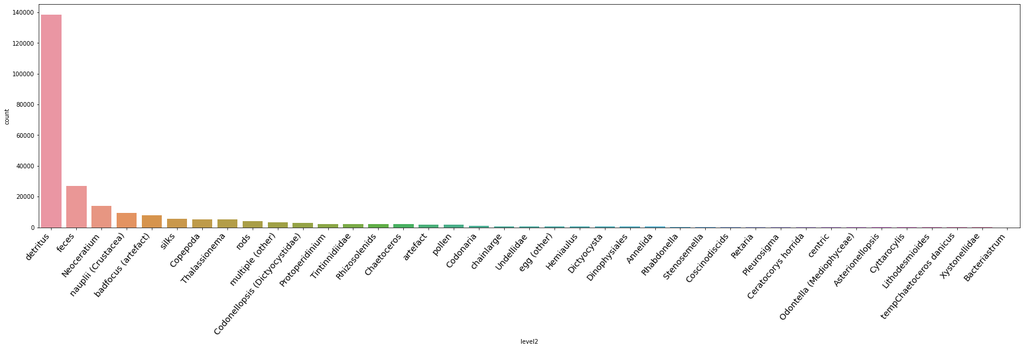

```python
fig = plt.figure(figsize=(30,7))
chart = sns.countplot(x='level2',
                      data=meta_lvl2,
                      order = meta_lvl2['level2'].value_counts().index)
chart.set_xticklabels(chart.get_xticklabels(),
                      rotation=50,
                      horizontalalignment='right',
                      fontweight='light',
                      fontsize='x-large');
```

```python
print('The proportion of detritus represents {}% in the whole dataset'.format(meta_lvl2['level2'].value_counts()[0]/len(meta_lvl2)*100))
```

```
The proportion of detritus represents 57.06306907879822% in the whole dataset
```

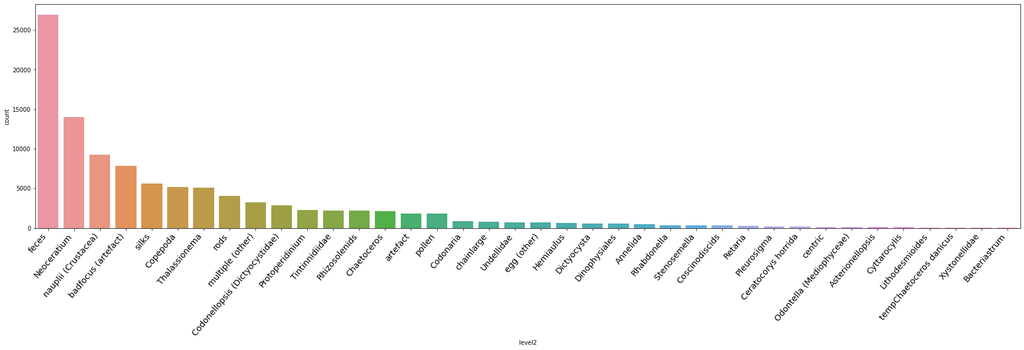

```python
#Without detritus
meta_lvl2_nod = meta_lvl2[meta_lvl2['level2']!='detritus']
fig = plt.figure(figsize=(30,7))
chart = sns.countplot(x='level2',
                      data=meta_lvl2_nod,
                      order = meta_lvl2_nod['level2'].value_counts().index)
chart.set_xticklabels(chart.get_xticklabels(),
                      rotation=50,
                      horizontalalignment='right',
                      fontweight='light',
                      fontsize='x-large');
```

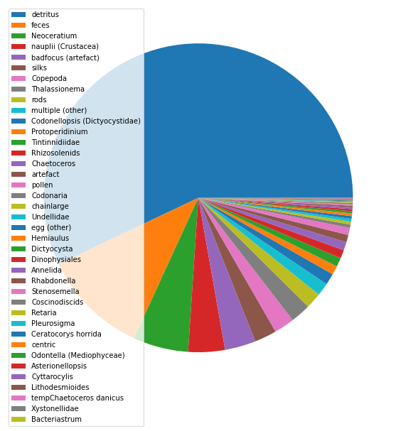

```python
fig = plt.figure(figsize=(10,10))
chart = plt.pie(x=meta_lvl2['level2'].value_counts())
plt.legend(chart[0], labels=meta_lvl2['level2'].value_counts().index)
plt.show()
```

## Working on images

### Data exploration: working on images

```python
data_set = pd.read_csv('/content/drive/My Drive/AML/Chal2 - Plankton/Data/data_set.csv')
```

```python
'''data_set = pd.DataFrame(columns=['objid', 'img', 'nb_rows', 'nb_columns'])

start = time()

for i, id in enumerate(objid):
  img = np.array(Image.open(img_files['imgs/{}.jpg'.format(int(id))]))
  #np_vect = np.reshape(img,(1,img.size))[0]
  data_set.loc[i] = [str(int(id))] + [img] + [len(img)] + [len(img[0])]

  if(i%1000==0):
    print(i)

end = time()
duration = end - start
print('Execution time: {}minutes'.format(duration/60))'''
```

[output not shown]

[output cut: 190 more lines]

```
230000
231000
232000
233000
234000
235000
236000
237000
238000
239000
240000
241000
242000
243000
Execution time: 118.00538615783056minutes
```

```python
data_set = data_set[['objid', 'nb_rows', 'nb_columns']]
data_set
```

|  | objid | nb_rows | nb_columns |
| --- | --- | --- | --- |
| 0 | 32756761 | 123 | 109 |
| 1 | 32759364 | 65 | 33 |
| 2 | 32758055 | 115 | 26 |
| 3 | 32758988 | 117 | 126 |
| 4 | 32760598 | 239 | 66 |
| ... | ... | ... | ... |
| 243605 | 31647316 | 199 | 153 |
| 243606 | 31070220 | 327 | 180 |
| 243607 | 31649437 | 220 | 124 |
| 243608 | 31125319 | 252 | 217 |
| 243609 | 31059938 | 245 | 140 |

243610 rows × 3 columns

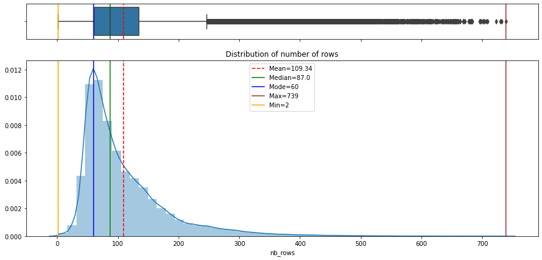

```python
f, (ax_box, ax_hist) = plt.subplots(2, sharex=True, gridspec_kw= {"height_ratios": (0.2, 1)}, figsize=(15,7))
plt.title('Distribution of number of rows')
mean = round(data_set['nb_rows'].mean(), 2)
median = round(data_set['nb_rows'].median(), 2)
mode = round(data_set['nb_rows'].mode()[0], 2)
maxi = round(data_set['nb_rows'].max(), 2)
mini = round(data_set['nb_rows'].min(), 2)

sns.boxplot(data_set['nb_rows'], ax=ax_box)
ax_box.axvline(mean, color='r', linestyle='--')
ax_box.axvline(median, color='g', linestyle='-')
ax_box.axvline(mode, color='b', linestyle='-')
ax_box.axvline(maxi, color='brown', linestyle='-')
ax_box.axvline(mini, color='orange', linestyle='-')

sns.distplot(data_set['nb_rows'], ax=ax_hist)
ax_hist.axvline(mean, color='r', linestyle='--')
ax_hist.axvline(median, color='g', linestyle='-')
ax_hist.axvline(mode, color='b', linestyle='-')
ax_hist.axvline(maxi, color='brown', linestyle='-')
ax_hist.axvline(mini, color='orange', linestyle='-')

plt.legend({'Mean={}'.format(mean):mean,
            'Median={}'.format(median):median,
            'Mode={}'.format(mode):mode,
            'Max={}'.format(maxi):maxi,
            'Min={}'.format(mini):mini},
           loc='upper center')

ax_box.set(xlabel='')
plt.show()
```

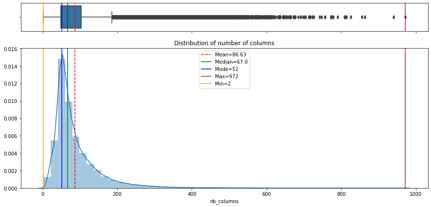

```python
f, (ax_box, ax_hist) = plt.subplots(2, sharex=True, gridspec_kw= {"height_ratios": (0.2, 1)}, figsize=(15,7))
plt.title('Distribution of number of columns')
mean = round(data_set['nb_columns'].mean(), 2)
median = round(data_set['nb_columns'].median(), 2)
mode = round(data_set['nb_columns'].mode()[0], 2)
maxi = round(data_set['nb_columns'].max(), 2)
mini = round(data_set['nb_columns'].min(), 2)

sns.boxplot(data_set['nb_columns'], ax=ax_box)
ax_box.axvline(mean, color='r', linestyle='--')
ax_box.axvline(median, color='g', linestyle='-')
ax_box.axvline(mode, color='b', linestyle='-')
ax_box.axvline(maxi, color='brown', linestyle='-')
ax_box.axvline(mini, color='orange', linestyle='-')

sns.distplot(data_set['nb_columns'], ax=ax_hist)
ax_hist.axvline(mean, color='r', linestyle='--')
ax_hist.axvline(median, color='g', linestyle='-')
ax_hist.axvline(mode, color='b', linestyle='-')
ax_hist.axvline(maxi, color='brown', linestyle='-')
ax_hist.axvline(mini, color='orange', linestyle='-')

plt.legend({'Mean={}'.format(mean):mean,
            'Median={}'.format(median):median,
            'Mode={}'.format(mode):mode,
            'Max={}'.format(maxi):maxi,
            'Min={}'.format(mini):mini},
           loc='upper center')

ax_box.set(xlabel='')
plt.show()
```

```python
data_set['nb_columns'].describe()
```

```
count    243610.000000
mean         86.628936
std          62.146386
min           2.000000
25%          49.000000
50%          67.000000
75%         104.000000
max         972.000000
Name: nb_columns, dtype: float64
```

```python
data_set['nb_rows'].describe()
```

```
count    243610.000000
mean        109.338582
std          71.930568
min           2.000000
25%          61.000000
50%          87.000000
75%         135.000000
max         739.000000
Name: nb_rows, dtype: float64
```

```python
data_set = data_set[(data_set['nb_columns']>=49) & (data_set['nb_rows']>=61)]
data_set
```

|  | objid | nb_rows | nb_columns |
| --- | --- | --- | --- |
| 0 | 32756761 | 123 | 109 |
| 3 | 32758988 | 117 | 126 |
| 4 | 32760598 | 239 | 66 |
| 5 | 32760828 | 146 | 197 |
| 6 | 32760820 | 186 | 160 |
| ... | ... | ... | ... |
| 243605 | 31647316 | 199 | 153 |
| 243606 | 31070220 | 327 | 180 |
| 243607 | 31649437 | 220 | 124 |
| 243608 | 31125319 | 252 | 217 |
| 243609 | 31059938 | 245 | 140 |

147917 rows × 3 columns

```python
data_set = pd.merge(data_set, meta_lvl2, left_on='objid', right_on='objid', how='inner')
data_set
```

[output not shown]

```python
data_set.to_csv('/content/drive/My Drive/AML/Chal2 - Plankton/Data/all_image_information.csv')
```

### Data pre-processing and Model selection

#### Data pre-processing: images exploitation approaches | Handmade CNN

```python
img_info_2 = pd.read_csv('/content/drive/My Drive/AML/Chal2 - Plankton/Data/all_image_information.csv').drop('Unnamed: 0', axis=1)
```

```python
img_info_2['nb_columns'].describe()
```

```
count    242607.000000
mean         86.608379
std          62.112025
min           2.000000
25%          49.000000
50%          67.000000
75%         104.000000
max         972.000000
Name: nb_columns, dtype: float64
```

```python
img_info_2['nb_rows'].describe()
```

```
count    242607.000000
mean        109.302926
std          71.937172
min           2.000000
25%          61.000000
50%          87.000000
75%         135.000000
max         739.000000
Name: nb_rows, dtype: float64
```

The median is at 67 for columns and 87 for rows. We can then reasonably choose to resize all images to 87X67.

```python
img_files = extract_zip_to_memory('/content/drive/My Drive/AML/Chal2 - Plankton/Data/imgs.zip')
```

```python
#img_info_2 = img_info_2.sample(frac=0.1, random_state=1)
img_info_2
```

|  | objid | nb_rows | nb_columns | level2 |
| --- | --- | --- | --- | --- |
| 0 | 32756761 | 123 | 109 | detritus |
| 1 | 32759364 | 65 | 33 | detritus |
| 2 | 32758055 | 115 | 26 | Rhizosolenids |
| 3 | 32758988 | 117 | 126 | silks |
| 4 | 32760598 | 239 | 66 | silks |
| ... | ... | ... | ... | ... |
| 242602 | 30974080 | 204 | 221 | Thalassionema |
| 242603 | 31070220 | 327 | 180 | Thalassionema |
| 242604 | 31649437 | 220 | 124 | nauplii (Crustacea) |
| 242605 | 31125319 | 252 | 217 | detritus |
| 242606 | 31059938 | 245 | 140 | detritus |

242607 rows × 4 columns

```python
img_info_2_aug = img_info_2[['objid', 'level2']]
img_info_2_aug
```

|  | objid | level2 |
| --- | --- | --- |
| 0 | 32756761 | detritus |
| 1 | 32759364 | detritus |
| 2 | 32758055 | Rhizosolenids |
| 3 | 32758988 | silks |
| 4 | 32760598 | silks |
| ... | ... | ... |
| 242602 | 30974080 | Thalassionema |
| 242603 | 31070220 | Thalassionema |
| 242604 | 31649437 | nauplii (Crustacea) |
| 242605 | 31125319 | detritus |
| 242606 | 31059938 | detritus |

242607 rows × 2 columns

We will create new images with new objid in order to do data augmentation and not negligate the poor classes.

```python
images = []
labels = []

#np.zeros(shape=(len(img_info_2),img_info_2[['level2']].nunique()['level2']))

objid = img_info_2[['objid']].to_numpy()
label = img_info_2[['level2']].to_numpy()
label_name = img_info_2['level2'].unique()

#Identifying the different level twos that are less present and we have to do data augmentatiin on it
different_species = img_info_2.groupby(['level2'])['objid'].count()

little_class = different_species.sort_values(ascending=True)[:20]
little_class = list(little_class.index.sort_values(ascending=True).values)
little_class

start = time()

j=0
#i=0
img_arrays = {}

for i, id in enumerate(objid):

  img = Image.open(img_files['imgs/{}.jpg'.format(int(id[0]))])
  img = img.resize((67,87), Image.ANTIALIAS)

  img = np.array(img)
  #img = np.divide((img),255)
  #img = img.astype('float16')
  images.append(img.reshape(87,67,1))

  label_encoded = np.zeros(shape=( 1, len(label_name)))
  label_encoded[0][np.argwhere(label_name==label[i][0])[0][0]] = 1

  labels.append(label_encoded[0])

  if(i%20000==0):
      print(i)



  if ( label[i][0] in little_class):
    #Getting the specie corresponding to this image to add a corresponding line to the meta
    specie = label[i][0]

    #Flipping left right
    img_arrays[j]=  np.fliplr(img)

    #Flipping Up Down
    img_arrays[j+1]=  np.flipud(img)

    #Rotating two times with two different angle
    img_arrays[j+2]= scipy.ndimage.rotate(img, float(randint(-30,30)), reshape=False, order=5, mode='nearest')

    img_arrays[j+3]= scipy.ndimage.rotate(img, float(randint(-30,30)), reshape=False, order=5, mode='nearest')

    #Adding a three new lines in our df (one for each modification) with the unique_name corresponding to the original image
    df = pd.DataFrame({'objid' :[j,j+1,j+2,j+3], 'level2' :[specie , specie ,specie ,specie]})
    img_info_2_aug = img_info_2_aug.append(df, ignore_index=True)
    j+=4


for i in range (j):
  img = np.array(img_arrays[i])
  #img = np.divide((img),255)
  #img = img.astype('float16')
  images.append(img.reshape(87,67,1))


  label_encoded = np.zeros(shape=( 1, len(label_name)))
  label_encoded[0][np.argwhere(label_name==img_info_2_aug.loc[img_info_2_aug['objid'] == i, 'level2'].values[0])[0][0]] = 1
  labels.append(label_encoded[0])

del img_arrays

end = time()
duration = end - start
print('Execution time: {}minutes'.format(duration/60))
```

```
0
20000
40000
60000
80000
100000
120000
140000
160000
180000
200000
220000
240000
Execution time: 2.4885857065518695minutes
```

```python
img_info_2['level2'].value_counts().index
```

```
Index(['detritus', 'feces', 'Neoceratium', 'nauplii (Crustacea)',
       'badfocus (artefact)', 'silks', 'Copepoda', 'Thalassionema', 'rods',
       'multiple (other)', 'Codonellopsis (Dictyocystidae)', 'Protoperidinium',
       'Tintinnidiidae', 'Rhizosolenids', 'Chaetoceros', 'artefact', 'pollen',
       'Codonaria', 'chainlarge', 'Undellidae', 'egg (other)', 'Hemiaulus',
       'Dictyocysta', 'Dinophysiales', 'Annelida', 'Rhabdonella',
       'Stenosemella', 'Coscinodiscids', 'Retaria', 'Pleurosigma',
       'Ceratocorys horrida', 'centric', 'Odontella (Mediophyceae)',
       'Asterionellopsis', 'Cyttarocylis', 'Lithodesmioides',
       'tempChaetoceros danicus', 'Xystonellidae', 'Bacteriastrum'],
      dtype='object')
```

```python
images[240000+2500].shape
#img.reshape(IMG_SIZE,IMG_SIZE,1)
```

```
(87, 67, 1)
```

Here with the data augmentation we obtained 23932 images more.

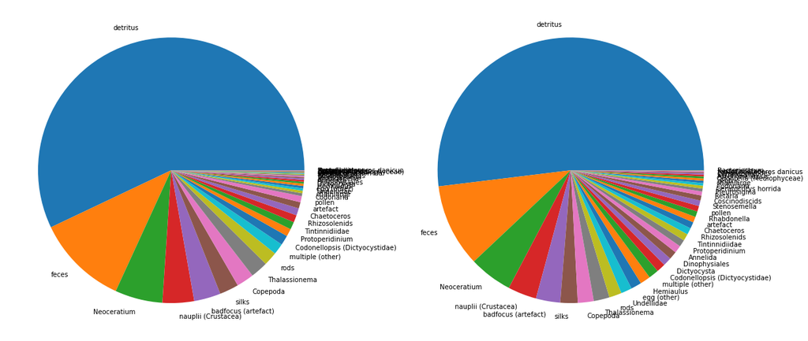

```python
fig = plt.figure(figsize=(20,20))
plt.subplot(121)
pie_labels = img_info_2['level2'].value_counts().index
chart = plt.pie(x=img_info_2['level2'].value_counts(), labels=pie_labels)
#plt.legend(chart[0], labels=img_info_2_aug['level2'].value_counts().index, bbox_to_anchor = (0,1))

#fig = plt.figure(figsize=(10,10))
plt.subplot(122)
pie_labels = img_info_2_aug['level2'].value_counts().index
chart = plt.pie(x=img_info_2_aug['level2'].value_counts(), labels=pie_labels)
#plt.legend(chart[0], labels=img_info_2['level2'].value_counts().index, bbox_to_anchor = (1,0))
plt.show()
```

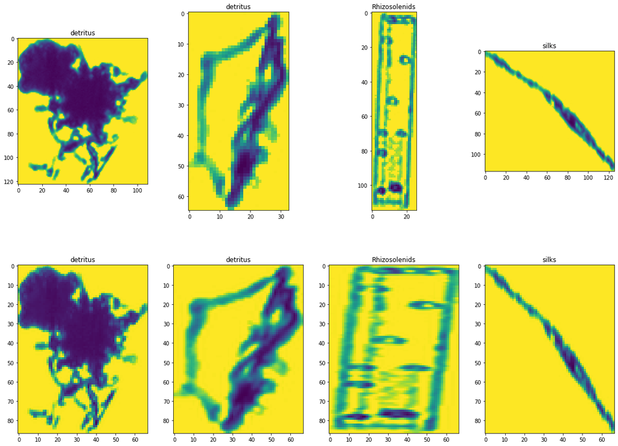

```python
fig = plt.figure(figsize = (20,15))
for i in range(4):
  plt.subplot((24)*10+(i+1))
  plt.title(label[i][0])
  real_img = np.array(Image.open(img_files['imgs/{}.jpg'.format(int(objid[i][0]))]))
  plt.imshow(real_img)

for i in range(4, 8):
  plt.subplot((24)*10+(i+1))
  plt.imshow(images[i-4].reshape(87,67))
  plt.title(label[i-4][0])
```

```python
del img_files
```

#### Model selection | Handmade CNN

```python
X = images
Y = labels

X_train, X_test, y_train, y_test = train_test_split(X, Y, test_size=0.20, stratify = labels,  random_state=42)
```

```python
X_train = np.array(X_train)
X_test = np.array(X_test)

y_train = np.array(y_train)
y_test = np.array(y_test)
```

```python
#Recall, precision and F1-score, the metrics that interest us

def recall_m(y_true, y_pred):
    true_positives = K.sum(K.round(K.clip(y_true * y_pred, 0, 1)))
    possible_positives = K.sum(K.round(K.clip(y_true, 0, 1)))
    recall = true_positives / (possible_positives + K.epsilon())
    return recall

def precision_m(y_true, y_pred):
    true_positives = K.sum(K.round(K.clip(y_true * y_pred, 0, 1)))
    predicted_positives = K.sum(K.round(K.clip(y_pred, 0, 1)))
    precision = true_positives / (predicted_positives + K.epsilon())
    return precision

def f1_m(y_true, y_pred):
    precision = precision_m(y_true, y_pred)
    recall = recall_m(y_true, y_pred)
    return 2*((precision*recall)/(precision+recall+K.epsilon()))
```

```python
##Function to build the CNN for different activation functions

def build_CNN(learning_rate ,dropout, x_train , y_train , x_test , y_test , epochs , batch_size):
    CNN = Sequential()
    CNN.add(Conv2D(32, kernel_size=(3, 3),
                     activation='relu',
                     input_shape=(87, 67, 1)))
    CNN.add(MaxPooling2D(pool_size=(2, 2)))

    CNN.add(Conv2D(32, kernel_size=(3, 3),
                     activation='relu'))
    CNN.add(MaxPooling2D(pool_size=(2, 2)))

    CNN.add(Conv2D(64, kernel_size=(3, 3),
                     activation='relu'))
    CNN.add(MaxPooling2D(pool_size=(2, 2)))

    CNN.add(Flatten())  # this converts our 3D feature maps to 1D feature vectors
    CNN.add(Dense(64, activation='relu'))
    CNN.add(Dropout(dropout))
    CNN.add(Dense(39, activation='softmax'))


    CNN.compile(loss=keras.losses.categorical_crossentropy,
              optimizer=keras.optimizers.Adadelta(lr = learning_rate),
              metrics=[f1_m,precision_m,recall_m])


    CNN.summary()

    history = CNN.fit(x_train, y_train,
              batch_size=batch_size,
              epochs=epochs,
              verbose=1,
              validation_data=(x_test, y_test))

    return(CNN)
```

```python
start_CNN = time()
sofmax_CNN = build_CNN(5 , 0.2, X_train , y_train , X_test , y_test , 10 ,128 )
end_CNN = time()
time_CNN = end_CNN - start_CNN
```

```
Model: "sequential_2"
_________________________________________________________________
Layer (type)                 Output Shape              Param #
=================================================================
conv2d_4 (Conv2D)            (None, 85, 65, 32)        320
_________________________________________________________________
max_pooling2d_4 (MaxPooling2 (None, 42, 32, 32)        0
_________________________________________________________________
conv2d_5 (Conv2D)            (None, 40, 30, 32)        9248
_________________________________________________________________
max_pooling2d_5 (MaxPooling2 (None, 20, 15, 32)        0
_________________________________________________________________
conv2d_6 (Conv2D)            (None, 18, 13, 64)        18496
_________________________________________________________________
max_pooling2d_6 (MaxPooling2 (None, 9, 6, 64)          0
_________________________________________________________________
flatten_2 (Flatten)          (None, 3456)              0
_________________________________________________________________
dense_3 (Dense)              (None, 64)                221248
_________________________________________________________________
dropout_2 (Dropout)          (None, 64)                0
_________________________________________________________________
dense_4 (Dense)              (None, 39)                2535
=================================================================
Total params: 251,847
Trainable params: 251,847
Non-trainable params: 0
_________________________________________________________________
Train on 213231 samples, validate on 53308 samples
```

```python
print('It took {}min to run'.format(time_CNN/60))
```

```
It took 5.527883438269297min to run
```

```python
def plot_confusion_matrix(cm, classes,
                          normalize=False,
                          title='Confusion matrix',
                          cmap=plt.cm.Blues):
    """
    Goal : This function prints and plots the confusion matrix.
    Normalization can be applied by setting `normalize=True`.
    """
    if normalize:
        cm = cm.astype('float') / cm.sum(axis=1)[:, np.newaxis]
        print("Normalized confusion matrix")
    else:
        print('Confusion matrix, without normalization')

    fig = plt.figure(figsize = (30,30))

    plt.imshow(cm, interpolation='nearest', cmap=cmap)
    plt.title(title)
    plt.colorbar()
    tick_marks = np.arange(len(classes))
    plt.xticks(tick_marks, classes, rotation=45, ha="right")
    plt.yticks(tick_marks, classes)

    fmt = '.2f' if normalize else 'd'
    thresh = cm.max() / 2.
    for i, j in itertools.product(range(cm.shape[0]), range(cm.shape[1])):
        plt.text(j, i, format(cm[i, j], fmt),
                 horizontalalignment="center",
                 color="white" if cm[i, j] > thresh else "black")

    plt.ylabel('True label')
    plt.xlabel('Predicted label')
    plt.tight_layout()
```

```python
y_pred = sofmax_CNN.predict(X_test)
```

```
Normalized confusion matrix
```

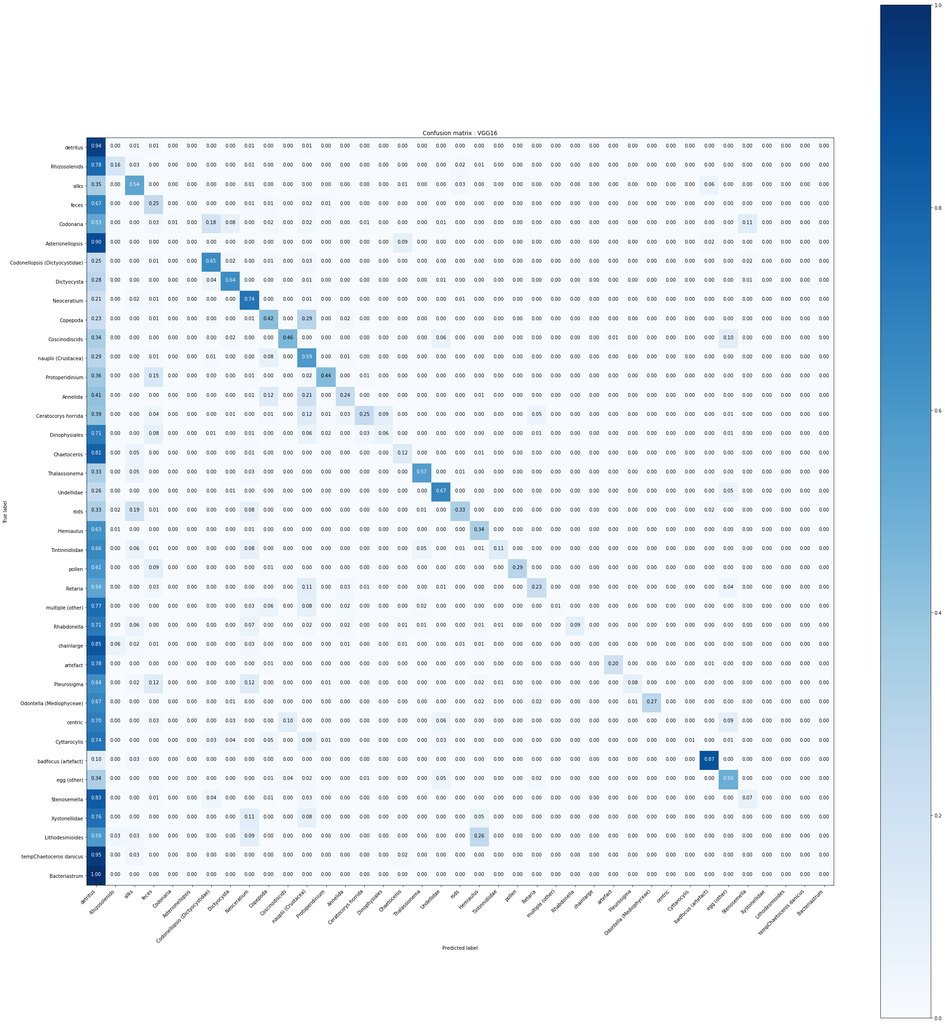

```python
from sklearn.metrics import confusion_matrix

# Compute confusion matrix
cnf_matrix = confusion_matrix(np.argmax(y_test, axis=1), np.argmax(y_pred, axis=1))
# Plot normalized confusion matrix
plt.figure()
plot_confusion_matrix(cnf_matrix, classes = label_name ,normalize=True)
plt.title("Confusion matrix : VGG16")
```

```python
y_pred_categorical = np.zeros_like(y_pred)
y_pred_categorical[np.arange(len(y_pred)), y_pred.argmax(1)] = 1
```

```python
score_sofmax = f1_score(y_pred_categorical , y_test , average = 'macro')
```

```python
print(score_sofmax)
```

```
0.332946324700707
```

```python
results_softmax = pd.DataFrame([['Softmax CNN', score_sofmax, time_CNN/60, len(img_info_2_aug)]], columns=['Model', 'f1_score', 'Training execution time (min)', 'Number of images involved'])
```

```python
results_softmax.to_csv('/content/drive/My Drive/AML/Chal2 - Plankton/Data/results_sofmax.csv')
```

#### Data pre-processing: images exploitation approaches | VGG16

Now that we have the correct amount of images and a clean dataframe with the only informations we need. Let's create the dataset for training our CNN.

```python
img_files = extract_zip_to_memory('/content/drive/My Drive/AML/Chal2 - Plankton/Data/imgs.zip')
```

```python
img_info = pd.read_csv('/content/drive/My Drive/AML/Chal2 - Plankton/Data/image_information.csv').drop('Unnamed: 0', axis=1)
img_info
```

|  | objid | nb_rows | nb_columns | level2 |
| --- | --- | --- | --- | --- |
| 0 | 32756761 | 123 | 109 | detritus |
| 1 | 32758988 | 117 | 126 | silks |
| 2 | 32760598 | 239 | 66 | silks |
| 3 | 32760828 | 146 | 197 | detritus |
| 4 | 32760820 | 186 | 160 | detritus |
| ... | ... | ... | ... | ... |
| 147162 | 30974080 | 204 | 221 | Thalassionema |
| 147163 | 31070220 | 327 | 180 | Thalassionema |
| 147164 | 31649437 | 220 | 124 | nauplii (Crustacea) |
| 147165 | 31125319 | 252 | 217 | detritus |
| 147166 | 31059938 | 245 | 140 | detritus |

147167 rows × 4 columns

```python
df0 = pd.DataFrame(columns=img_info.columns.to_list())

for lvl2 in img_info['level2'].unique():
  df1 = img_info[img_info['level2']==lvl2].sample(frac=0.1, random_state=1)
  df0 = pd.concat([df0, df1])

img_info = df0
img_info = img_info.sample(frac=1, random_state=1)
img_info
```

|  | objid | nb_rows | nb_columns | level2 |
| --- | --- | --- | --- | --- |
| 77675 | 32653573 | 68 | 65 | detritus |
| 134063 | 32534716 | 146 | 299 | detritus |
| 96469 | 32607888 | 63 | 95 | detritus |
| 93517 | 32577301 | 72 | 58 | detritus |
| 94672 | 32709811 | 136 | 233 | silks |
| ... | ... | ... | ... | ... |
| 32495 | 32742835 | 77 | 78 | detritus |
| 12707 | 32659224 | 123 | 64 | detritus |
| 80969 | 32744018 | 126 | 159 | nauplii (Crustacea) |
| 32882 | 32617472 | 61 | 58 | detritus |
| 92827 | 32559409 | 233 | 127 | Thalassionema |

14716 rows × 4 columns

```python
img_info = img_info.sample(frac=1, random_state=1)
img_info[['level2']].nunique()
```

```
level2    39
dtype: int64
```

```python
img_info = img_info.sample(frac=1, random_state=1)
img_info = img_info.sample(frac=1, random_state=1)
img_info
```

|  | objid | nb_rows | nb_columns | level2 |
| --- | --- | --- | --- | --- |
| 40073 | 32751971 | 101 | 63 | Rhizosolenids |
| 119018 | 32700032 | 63 | 49 | detritus |
| 113199 | 32632608 | 118 | 87 | nauplii (Crustacea) |
| 11963 | 32634948 | 63 | 60 | detritus |
| 692 | 32634924 | 67 | 85 | Codonellopsis (Dictyocystidae) |
| ... | ... | ... | ... | ... |
| 42985 | 32618794 | 164 | 163 | Neoceratium |
| 145864 | 31270129 | 166 | 157 | Chaetoceros |
| 83598 | 32643995 | 68 | 134 | detritus |
| 94975 | 32709541 | 300 | 53 | silks |
| 130515 | 32630713 | 123 | 72 | detritus |

14716 rows × 4 columns

```python
img_info_aug = img_info[['objid', 'level2']]
img_info_aug
```

|  | objid | level2 |
| --- | --- | --- |
| 40073 | 32751971 | Rhizosolenids |
| 119018 | 32700032 | detritus |
| 113199 | 32632608 | nauplii (Crustacea) |
| 11963 | 32634948 | detritus |
| 692 | 32634924 | Codonellopsis (Dictyocystidae) |
| ... | ... | ... |
| 42985 | 32618794 | Neoceratium |
| 145864 | 31270129 | Chaetoceros |
| 83598 | 32643995 | detritus |
| 94975 | 32709541 | silks |
| 130515 | 32630713 | detritus |

14716 rows × 2 columns

```python
images = []
labels = []

objid = img_info[['objid']].to_numpy()
label = img_info[['level2']].to_numpy()
label_name = img_info['level2'].unique()

j=0
#i=0

img_arrays = {}

#Identifying the different level twos that are less present and we have to do data augmentatiin on it
different_species = img_info.groupby(['level2'])['objid'].count()

little_class = different_species.sort_values(ascending=True)[:10]
little_class = list(little_class.index.sort_values(ascending=True).values)
little_class

start = time()

for i, id in enumerate(objid):
  #Loading and resizing the image in order to make it fit to the VGG16 model
  img = Image.open(img_files['imgs/{}.jpg'.format(int(id[0]))])
  img = img.resize((224,224), Image.ANTIALIAS)

  #Storing the array image
  img = np.array(img)
  images.append(color.gray2rgb(img))


  label_encoded = np.zeros(shape=( 1, len(label_name)))
  label_encoded[0][np.argwhere(label_name==label[i][0])[0][0]] = 1

  labels.append(label_encoded[0])

  if(i%1000==0):
      print(i)

  if ( label[i][0] in little_class):
    #Getting the specie corresponding to this image to add a corresponding line to the meta
    specie = label[i][0]

    #Flipping left right
    img_arrays[j]=  np.fliplr(img)

    #Flipping Up Down
    img_arrays[j+1]=  np.flipud(img)

    #Rotating two times with two different angle
    img_arrays[j+2]= scipy.ndimage.rotate(img, float(randint(-30,30)), reshape=False, order=5, mode='nearest')

    img_arrays[j+3]= scipy.ndimage.rotate(img, float(randint(-30,30)), reshape=False, order=5, mode='nearest')

    #Adding a three new lines in our df (one for each modification) with the unique_name corresponding to the original image
    df = pd.DataFrame({'objid' :[j,j+1,j+2,j+3], 'level2' :[specie , specie ,specie ,specie]})
    img_info_aug = img_info_aug.append(df, ignore_index=True)
    j+=4


for i in range (j):
  img = np.array(img_arrays[i])
  #img = np.divide((img),255)
  #img = img.astype('float16')
  images.append(color.gray2rgb(img))


  label_encoded = np.zeros(shape=( 1, len(label_name)))
  label_encoded[0][np.argwhere(label_name==img_info_aug.loc[img_info_aug['objid'] == i, 'level2'].values[0])[0][0]] = 1
  labels.append(label_encoded[0])

del img_arrays

end = time()
duration = end - start
print('Execution time: {}minutes'.format(duration/60))
```

```
0
1000
2000
3000
4000
5000
6000
7000
8000
9000
10000
11000
12000
13000
14000
Execution time: 0.28157357772191366minutes
```

Printing some images

```python
img_info[['objid', 'level2']].to_numpy()[:,0]
```

```
array([32751971, 32700032, 32632608, ..., 32643995, 32709541, 32630713],
      dtype=object)
```

Quick look at the picture

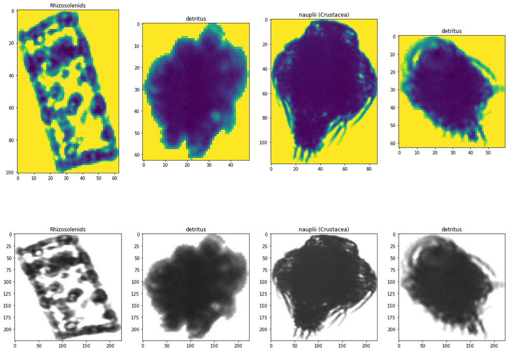

```python
fig = plt.figure(figsize = (20,15))
for i in range(4):
  plt.subplot((24)*10+(i+1))
  plt.title(label[i][0])
  real_img = np.array(Image.open(img_files['imgs/{}.jpg'.format(int(objid[i][0]))]))
  plt.imshow(real_img)

for i in range(4, 8):
  plt.subplot((24)*10+(i+1))
  plt.imshow(images[i-4])
  plt.title(label[i-4][0])
```

```python
del img_files
```

#### Model selection | VGG16

```python
X = images
Y = labels
```

```python
X_train, X_test, y_train, y_test = train_test_split(X, Y, test_size=0.20, random_state=42)
```

```python
vggmodel = VGG16(weights='imagenet', include_top=True)
x = vggmodel.layers[-2].output
#We just add the last Dense layer
predictions = Dense(39, activation="sigmoid")(x)
vgg_model = Model(input = vggmodel.input, output = predictions)
```

```
Downloading data from https://github.com/fchollet/deep-learning-models/releases/download/v0.1/vgg16_weights_tf_dim_ordering_tf_kernels.h5
```

```python
#Compilation
vgg_model.compile(loss='binary_crossentropy',
                  optimizer=keras.optimizers.SGD(lr=2e-3, momentum=0.9),
                  metrics=[f1_m,precision_m,recall_m])
```

```python
#Saving the model (it's going to be useful for next parts)
filepath = '/content/drive/My Drive/AML/Chal2 - Plankton/Data/weights_vgg(f1).hdf5'
filepath2 = '/content/drive/My Drive/AML/Chal2 - Plankton/Data/weights_vgg(loss).hdf5'
```

```python
#Save where the val_f1_m is the best
checkpoint1 = ModelCheckpoint(filepath, monitor='val_f1_m', verbose=0, save_weights_only=True,
                                                 save_best_only=True, mode='max', period=1)
#Save when the val_loss function is at its min
checkpoint2 = ModelCheckpoint(filepath2, monitor='val_loss', verbose=0, save_weights_only=True,
                                                 save_best_only=True, mode='min', period=1)
```

```python
'''datagen = ImageDataGenerator()
train = datagen.flow(np.array(X_train), y_train, batch_size=100)
test = datagen.flow(np.array(X_test), y_test, batch_size=100)'''
epoch = 10

X_train = np.array(X_train)
X_test = np.array(X_test)

y_train = np.array(y_train)
y_test = np.array(y_test)

start_VGG16 = time()
history_vgg=vgg_model.fit(X_train,
                          y_train,
                          validation_split = 0.2,
                          batch_size = 32,
                          nb_epoch=epoch,
                          callbacks=[checkpoint1,checkpoint2])
end_VGG16 = time()
time_VGG16 = end_VGG16 - start_VGG16
```

```
Train on 9574 samples, validate on 2394 samples
```

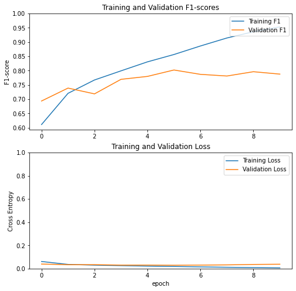

```python
#Bilan
acc = history_vgg.history['f1_m']
val_acc = history_vgg.history['val_f1_m']
loss = history_vgg.history['loss']
val_loss = history_vgg.history['val_loss']

plt.figure(figsize=(8, 8))
plt.subplot(2, 1, 1)
plt.plot(acc, label='Training F1')
plt.plot(val_acc, label='Validation F1')
plt.legend(loc='upper right')
plt.ylabel('F1-score')
plt.ylim([min(plt.ylim()),1])
plt.title('Training and Validation F1-scores')

plt.subplot(2, 1, 2)
plt.plot(loss, label='Training Loss')
plt.plot(val_loss, label='Validation Loss')
plt.legend(loc='upper right')
plt.ylabel('Cross Entropy')
plt.ylim([0,1.0])
plt.title('Training and Validation Loss')
plt.xlabel('epoch')
plt.show()
```

```python
y_pred=vgg_model.predict(X_test)
```

```
Normalized confusion matrix
```

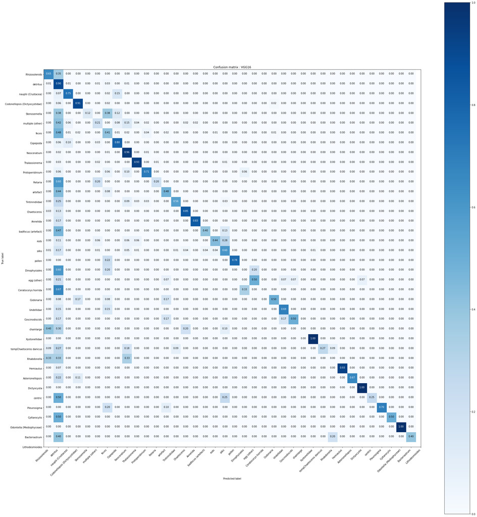

```python
from sklearn.metrics import confusion_matrix

# Compute confusion matrix
cnf_matrix = confusion_matrix(np.argmax(y_test, axis=1), np.argmax(y_pred, axis=1))
# Plot normalized confusion matrix
plt.figure()
plot_confusion_matrix(cnf_matrix, classes = label_name ,normalize=True)
plt.title("Confusion matrix : VGG16")
```

```python
y_pred_categorical = np.zeros_like(y_pred)
y_pred_categorical[np.arange(len(y_pred)), y_pred.argmax(1)] = 1
```

```python
score_VGG16 = f1_score(y_pred_categorical , y_test , average = 'macro')
```

```python
score_VGG16
```

```
0.5649628867401619
```

```python
time_VGG16/60
```

```
27.31682934363683
```

```python
results_VGG16 = pd.DataFrame([['VGG16', score_VGG16, time_VGG16/60, len(img_info_aug)]], columns=['Model', 'f1_score', 'Training execution time (min)', 'Number of images involved'])
results = pd.concat([results_softmax, results_VGG16])
results.to_csv('/content/drive/My Drive/AML/Chal2 - Plankton/Data/final_results.csv')

results
```

|  | Model | f1_score | Training execution time (min) | Number of images involved |
| --- | --- | --- | --- | --- |
| 0 | Softmax CNN | 0.332946 | 5.527883 | 266539 |
| 0 | VGG16 | 0.564963 | 27.316829 | 14960 |

## Working on features

### Data exploration: features exploitation approach

In addition to the images, the meta.csv file containing metadata about the images, and the taxo.csv file defining the taxonomy tree we have two other csv files.

- `features_native.csv.gz` contains the morphological handcrafted features computed by ZooProcess. In fact, ZooProcess generates the region of interests (ROI) around each individual object from a original image of Plankton. In addition, it also computes a set of associated features measured on the object. These features are the ones contained in `features_native.csv.gz`
- `features_skimage.csv.gz` contains the morphological features recomputed with skimage.measure.regionprops on the ROIs produced by ZooProcess.

These two files contain information extracted from the images in form of features. This ZooProcess method is a software developped by an engineer from the Laboratoire d’Océanologie de Villefranche sur mer. During the next cells, we will try to explore and process these two files, in order to apply directly learning methods.

```python
features_native = pd.read_csv('/content/drive/My Drive/AML/Chal2 - Plankton/Data/features_native.csv',
                         sep=',',
                         header='infer')

display(features_native.loc[features_native['objid'] == 31649437])
```

|  | objid | area | meanimagegrey | mean | stddev | min | perim. | width | height | major | minor | angle | circ. | feret | intden | median | skew | kurt | %area | area_exc | fractal | skelarea | slope | histcum1 | histcum2 | histcum3 | nb1 | nb2 | nb3 | … |
| --- | --- | --- | --- | --- | --- | --- | --- | --- | --- | --- | --- | --- | --- | --- | --- | --- | --- | --- | --- | --- | --- | --- | --- | --- | --- | --- | --- | --- | --- | --- |
| 243607 | 31649437.0 | 6977.0 | 167.35 | 234.19 | 42.121 | 96 | 968.25 | 124 | 220 | 257.3 | 148.9 | 90 | 0.094 | 221.2 | 7048043.0 | 255 | -1.901 | 2.051 | 95.2 | 335.0 | 1.008 | 30096.0 | 2.559 | 155 | 244 | 252 | 20 | 3 | 1 | … |

```python
features_skimage = pd.read_csv('/content/drive/My Drive/AML/Chal2 - Plankton/Data/features_skimage.csv',
                         sep=',',
                         header='infer')

display(features_skimage.loc[features_skimage['objid'] == 31649437])
```

|  | objid | area | convex_area | eccentricity | equivalent_diameter | euler_number | filled_area | inertia_tensor0 | inertia_tensor1 | inertia_tensor2 | inertia_tensor3 | inertia_tensor_eigvals0 | inertia_tensor_eigvals1 | major_axis_length | max_intensity | mean_intensity | min_intensity | minor_axis_length | moments_hu0 | moments_hu1 | moments_hu2 | moments_hu3 | moments_hu4 | moments_hu5 | moments_hu6 | moments_normalized0 | moments_normalized1 | moments_normalized2 | moments_normalized3 | … |
| --- | --- | --- | --- | --- | --- | --- | --- | --- | --- | --- | --- | --- | --- | --- | --- | --- | --- | --- | --- | --- | --- | --- | --- | --- | --- | --- | --- | --- | --- | --- |
| 113079 | 31649437.0 | 6642.0 | 13694.0 | 0.898434 | 91.961171 | -40 | 6974.0 | 541.688916 | 497.668588 | 497.668588 | 1495.720186 | 1708.065081 | 329.344022 | 165.314976 | 220 | 143.620145 | 19 | 72.591352 | 3.067463e+08 | 4.308787e+07 | 6.335784e+06 | 1.040673e+06 | 1742.360302 | 164606.270376 | 2026.061169 | NaN | NaN | 2.251912e+08 | -3.468239e+07 | … |

First, we will remove rows corresponding to the unclassified images.

```python
features_native_lvl2 = features_native
features_skimage_lvl2 = features_skimage

for x in objid_toremove :
    features_native_lvl2 = features_native_lvl2[features_native_lvl2.objid != x]
    features_skimage_lvl2 = features_skimage_lvl2[features_skimage_lvl2.objid != x]
```

### Data pre-processing: features exploitation approach

#### Metadata

The meta dataset can be useful, but let's first remove all columns that are useless. There is only information relative to the images, the projects (when the image was taken for example). We will only keep objid and the label, hence level2.

In a way, this became our target dataframe.

```python
metadata = clean_meta[['objid','level2']]
```

```python
metadata.head()
```

|  | objid | level2 |
| --- | --- | --- |
| 0 | 32756761.0 | detritus |
| 1 | 32759364.0 | detritus |
| 2 | 32758055.0 | Rhizosolenids |
| 3 | 32758988.0 | silks |
| 4 | 32760598.0 | silks |

#### features_skimage

Let's look at the missing values in features_skimage.

```python
train_na = (features_skimage_lvl2.isnull().sum() / len(features_skimage_lvl2)) * 100
train_na = train_na.drop(train_na[train_na == 0].index).sort_values(ascending=False)[:30]
missing_data = pd.DataFrame({'Table 1: Missing Ratio' :train_na})
missing_data.head(20)
```

|  | Table 1: Missing Ratio |
| --- | --- |
| weighted_moments_normalized4 | 100.0 |
| weighted_moments_normalized1 | 100.0 |
| weighted_moments_normalized0 | 100.0 |
| moments_normalized4 | 100.0 |
| moments_normalized1 | 100.0 |
| moments_normalized0 | 100.0 |

Here, there are NaN values in only 6 different columns, which are full of NaN values, we'll then simply remove these columns.

```python
features_skimage_data = features_skimage_lvl2.drop(['moments_normalized0', 'moments_normalized1', 'moments_normalized4',
                                           'weighted_moments_normalized0', 'weighted_moments_normalized1', 'weighted_moments_normalized4'], axis=1)
```

#### features_native

```python
features_native_lvl2.isnull().sum().sort_values(ascending=False)[:20]
```

```
perimareaexc      34302
feretareaexc      34302
cdexc             34302
skeleton_area      6854
nb1_area           6854
symetrieh_area     6854
symetriev_area     6854
convarea_area      6854
nb2_area           6854
nb3_area           6854
slope                 0
feret                 0
skelarea              0
fractal               0
area_exc              0
histcum1              0
%area                 0
kurt                  0
skew                  0
histcum2              0
dtype: int64
```

These are all numerical features, we'll simply replace each NaN values by the corresponding mean.

```python
features_native_nan = features_native_lvl2.columns[features_native_lvl2.isnull().any()].tolist()
features_native_data = features_native_lvl2
for feature in features_native_nan:
  features_native_data[feature] = features_native_data[feature].fillna(features_native_data[feature].mean()) #filling Nan values with mean
```

#### Merging the three datasets

We first merge the three datasets, not taking care of any redudancy. Later on, we'll check if there are features highly correlated, in order to deal with redudancy.

```python
temp = pd.merge(features_native_data, features_skimage_data, left_on = 'objid', right_on='objid', how='inner')
features_data = pd.merge(temp, metadata, left_on = 'objid', right_on='objid', how='inner')
```

```python
features_data.head()
```

|  | objid | area_x | meanimagegrey | mean | stddev | min | perim. | width | height | major | minor | angle | circ. | feret | intden | median | skew | kurt | %area | area_exc | fractal | skelarea | slope | histcum1 | histcum2 | histcum3 | nb1 | nb2 | nb3 | … |
| --- | --- | --- | --- | --- | --- | --- | --- | --- | --- | --- | --- | --- | --- | --- | --- | --- | --- | --- | --- | --- | --- | --- | --- | --- | --- | --- | --- | --- | --- | --- |
| 0 | 32756761.0 | 6653.0 | 167.18 | 205.76 | 65.341 | 85 | 779.66 | 109 | 123 | 147.8 | 132.0 | 90 | 0.138 | 128.8 | 3153711.0 | 253 | -0.804 | -1.142 | 94.71 | 352.0 | 1.012 | 15327.0 | 0.802 | 100 | 146 | 238 | 3 | 3 | 10 | … |
| 1 | 32759364.0 | 1275.0 | 165.83 | 234.29 | 38.562 | 98 | 186.99 | 33 | 65 | 82.4 | 46.3 | 90 | 0.458 | 67.2 | 701229.0 | 255 | -1.903 | 2.434 | 68.31 | 404.0 | 1.026 | 2993.0 | 0.110 | 167 | 216 | 246 | 4 | 2 | 1 | … |
| 2 | 32758055.0 | 2416.0 | 167.92 | 239.15 | 25.590 | 94 | 276.33 | 26 | 115 | 138.8 | 38.4 | 90 | 0.398 | 115.6 | 1000126.0 | 255 | -2.147 | 5.385 | 65.60 | 831.0 | 1.050 | 4182.0 | 0.183 | 205 | 229 | 243 | 2 | 9 | 18 | … |
| 3 | 32758988.0 | 1433.0 | 167.34 | 248.79 | 20.933 | 107 | 388.40 | 126 | 117 | 151.2 | 141.0 | 0 | 0.119 | 171.3 | 4167272.0 | 255 | -4.124 | 17.007 | 100.00 | 0.0 | 1.185 | 16594.0 | 1.607 | 251 | 252 | 253 | 0 | 0 | 4 | … |
| 4 | 32760598.0 | 1650.0 | 166.89 | 250.42 | 14.603 | 124 | 751.96 | 66 | 239 | 278.7 | 83.5 | 90 | 0.037 | 244.4 | 4577141.0 | 255 | -4.376 | 20.118 | 95.82 | 69.0 | 1.013 | 18278.0 | 1.825 | 242 | 251 | 252 | 5 | 14 | 10 | … |

5 rows × 125 columns

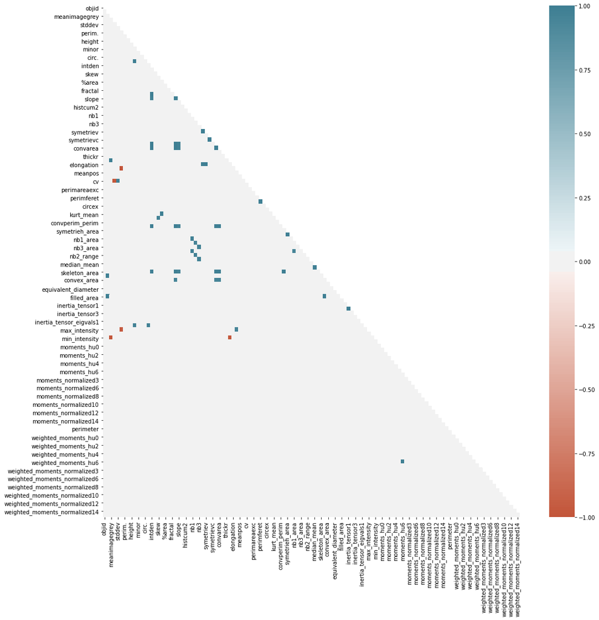

```python
corrMatrix = features_data.corr()
corrMatrix[np.abs(corrMatrix) <= 0.95] = 0
mask = np.zeros_like(corrMatrix)
mask[np.triu_indices_from(mask)] = True
plt.figure(figsize=(17,17))
sns.heatmap(corrMatrix, vmin = 1, vmax = -1, cmap=sns.diverging_palette(20, 220, n=200), mask = mask)
plt.show()
```

```python
column_names = list(features_data.columns.values)
column_names.pop(column_names.index('level2'))

col_redundant = []
for col in column_names :
    corr = corrMatrix[col].where(corrMatrix[col] > 0.95).dropna().index.values[0]
    if (corr != col):
        print(corr, ' with ', col, ' gives correlation > 0.95')
        col_redundant.append(col)
print()
print("So, the columns that are to correlated to others are the following : ", col_redundant)
```

```
major  with  feret  gives correlation > 0.95
intden  with  skelarea  gives correlation > 0.95
intden  with  slope  gives correlation > 0.95
symetrieh  with  symetriev  gives correlation > 0.95
symetriehc  with  symetrievc  gives correlation > 0.95
intden  with  convperim  gives correlation > 0.95
intden  with  convarea  gives correlation > 0.95
meanimagegrey  with  esd  gives correlation > 0.95
symetrieh  with  elongation  gives correlation > 0.95
stddev  with  cv  gives correlation > 0.95
perimferet  with  perimmajor  gives correlation > 0.95
kurt  with  kurt_mean  gives correlation > 0.95
skew  with  skew_mean  gives correlation > 0.95
intden  with  convarea_area  gives correlation > 0.95
symetrieh_area  with  symetriev_area  gives correlation > 0.95
nb1  with  nb1_area  gives correlation > 0.95
nb2  with  nb2_area  gives correlation > 0.95
nb3  with  nb3_area  gives correlation > 0.95
nb1  with  nb1_range  gives correlation > 0.95
nb2  with  nb2_range  gives correlation > 0.95
nb3  with  nb3_range  gives correlation > 0.95
median_mean  with  median_mean_range  gives correlation > 0.95
intden  with  skeleton_area  gives correlation > 0.95
area_x  with  area_y  gives correlation > 0.95
skelarea  with  convex_area  gives correlation > 0.95
area_x  with  filled_area  gives correlation > 0.95
inertia_tensor1  with  inertia_tensor2  gives correlation > 0.95
major  with  major_axis_length  gives correlation > 0.95
range  with  max_intensity  gives correlation > 0.95
moments_hu6  with  weighted_moments_hu6  gives correlation > 0.95

So, the columns that are to correlated to others are the following :  ['feret', 'skelarea', 'slope', 'symetriev', 'symetrievc', 'convperim', 'convarea', 'esd', 'elongation', 'cv', 'perimmajor', 'kurt_mean', 'skew_mean', 'convarea_area', 'symetriev_area', 'nb1_area', 'nb2_area', 'nb3_area', 'nb1_rang…
```

```python
features_dataset_final = features_data.drop(col_redundant, axis=1)
```

```python
#separating into inputs and target columns

X_features = features_dataset_final.drop('level2', axis=1)
y_features = features_dataset_final['level2']
```

Executing learning methods to this huge dataset takes too much time, we will then simply random sample it (10%). This will allow us to select models more rapidly and effectively.

```python
features_dataset_10p = features_dataset_final.sample(frac=0.1)

X_features_10p = features_dataset_10p.drop('level2', axis=1)
y_features_10p = features_dataset_10p['level2']
```

```python
#normalizing X
from sklearn.preprocessing import MinMaxScaler

sc = MinMaxScaler()
X_features_norm = sc.fit_transform(X_features)

sc5p = MinMaxScaler()
X_features_10p_norm = sc.fit_transform(X_features_10p)
```

```python
from sklearn.model_selection import train_test_split

X_features_train, X_features_test, y_features_train, y_features_test = train_test_split(X_features_norm, y_features, test_size=0.2, random_state=42, stratify=y_features)
X_features_10p_train, X_features_10p_test, y_features_10p_train, y_features_10p_test = train_test_split(X_features_10p_norm, y_features_10p, test_size=0.2, random_state=42, stratify=y_features_10p)
```

```python
pd.DataFrame(X_features_10p_train).to_csv('/content/drive/My Drive/AML/Chal2 - Plankton/Data/X_features_10p_train.csv', index=False)
pd.DataFrame(X_features_10p_test).to_csv('/content/drive/My Drive/AML/Chal2 - Plankton/Data/X_features_10p_test.csv', index=False)
pd.DataFrame(y_features_10p_train).to_csv('/content/drive/My Drive/AML/Chal2 - Plankton/Data/y_features_10p_train.csv', index=False)
pd.DataFrame(y_features_10p_test).to_csv('/content/drive/My Drive/AML/Chal2 - Plankton/Data/y_features_10p_test.csv', index=False)
```

### Model selection: features approach

Here, we define a function using a cross-validation strategy, in order to validate more accurately our models. Using KFold and shuffling(cross-validation) and using cross_val_score with the right scoring.

```python
#Validation function
from sklearn.model_selection import KFold, cross_val_score

n_folds = 5

def f1_cv(model, X, y):
    kf = KFold(n_folds, shuffle=True, random_state=42).get_n_splits(X)
    f1 = cross_val_score(model, X, y, scoring="f1_macro", cv = kf)
    return(f1)
```

#### KNN Classifier

```python
from sklearn.neighbors import KNeighborsClassifier
import time
start = time.time()
knn = KNeighborsClassifier()

f1_knn = f1_cv(knn, X_features_10p_train, y_features_10p_train)
end = time.time()
print("It takes ", end - start , " seconds to run")
```

```
It takes  19.999401092529297  seconds to run
```

```python
f1_knn
```

```
array([0.29506712, 0.29521257, 0.30545408, 0.29434144, 0.28307698])
```

```python
from sklearn.metrics import f1_score, roc_auc_score, classification_report

knn = KNeighborsClassifier(n_neighbors=3, n_jobs=39)

knn.fit(X_features_10p_train, y_features_10p_train)
y_pred_knn = knn.predict(X_features_10p_train)

print(classification_report(y_features_10p_train, y_pred_knn))
```

```
                                precision    recall  f1-score   support

                      Annelida       0.47      0.57      0.52        44
              Asterionellopsis       0.44      0.70      0.54        10
                 Bacteriastrum       1.00      1.00      1.00         2
           Ceratocorys horrida       0.43      0.46      0.44        13
                   Chaetoceros       0.65      0.67      0.66       154
                     Codonaria       0.45      0.74      0.56        76
Codonellopsis (Dictyocystidae)       0.69      0.88      0.78       230
                      Copepoda       0.73      0.85      0.78       383
                Coscinodiscids       0.61      0.65      0.63        26
                  Cyttarocylis       0.50      0.44      0.47         9
                   Dictyocysta       0.46      0.53      0.49        53
                 Dinophysiales       0.59      0.38      0.46        34
                     Hemiaulus       0.55      0.62      0.58        50
               Lithodesmioides       0.67      0.33      0.44         6
                   Neoceratium       0.78      0.87      0.82      1117
      Odontella (Mediophyceae)       1.00      0.20      0.33        10
                   Pleurosigma       0.56      0.33      0.42        15
               Protoperidinium       0.53      0.57      0.55       180
                       Retaria       0.50      0.57      0.53        14
                   Rhabdonella       0.63      0.57      0.60        30
                 Rhizosolenids       0.70      0.53      0.60       153
                  Stenosemella       0.43      0.67      0.52        30
                 Thalassionema       0.82      0.84      0.83       442
                Tintinnidiidae       0.71      0.54      0.61       178
                    Undellidae       0.71      0.67      0.69        51
                 Xystonellidae       0.00      0.00      0.00         2
                      artefact       0.77      0.71      0.74       156
           badfocus (artefact)       0.96      0.95      0.96       615
                       centric       0.58      0.54      0.56        13
                    chainlarge       0.64      0.28      0.39        64
                      detritus       0.88      0.93      0.91     11140
                   egg (other)       0.85      0.51      0.64        57
                         feces       0.86      0.70      0.77      2119
              multiple (other)       0.70      0.22      0.34       242
           nauplii (Crustacea)       0.85      0.72      0.78       785
                        pollen       0.62      0.37      0.46       148
                          rods       0.85      0.73      0.79       310
                         silks       0.94      0.77      0.85       441
       tempChaetoceros danicus       0.00      0.00      0.00         6

                      accuracy                           0.85     19408
                     macro avg       0.64      0.58      0.59     19408
                  weighted avg       0.84      0.85      0.84     19408
```

```
19.848445892333984
1
```

```
29.723628520965576
2
```

```
31.32709836959839
3
```

```
32.53696131706238
4
```

```
33.39685416221619
5
```

```
34.235743045806885
6
```

```
34.885547161102295
7
```

```
34.9395694732666
8
```

```
35.51619625091553
9
```

```
36.106257915496826
10
```

```
36.922441720962524
11
```

```
37.26072978973389
12
```

```
37.53861951828003
13
```

```
37.82809829711914
14
```

```
38.009194135665894
15
```

```
38.03487420082092
16
```

```
38.29376244544983
17
```

```
39.203102350234985
18
```

```
40.183401346206665
19
```

[figure not shown]

```python
#optimizing the parameter k
from sklearn.metrics import roc_curve

neighbors = [x for x in range(1,20)]

train_results = []

for n in neighbors:
  start= time.time()
  knn = KNeighborsClassifier(n_neighbors=n)
  knn.fit(X_features_10p_train, y_features_10p_train)
  train_pred = knn.predict(X_features_10p_train)
  #print(classification_report(y_features_10p_train, train_pred))
  train_results.append(np.mean(f1_cv(knn, X_features_10p_train, y_features_10p_train)))
  end = time.time()
  print(end - start)
  print(n)

fig = plt.figure(figsize=(10,8))
plt.plot(neighbors, train_results)
plt.ylabel('F1 CV')
plt.xlabel('neighbors')
plt.show()
```

```python
train_results
```

```
[0.33275709010926896,
 0.3178066538523502,
 0.3163337877372139,
 0.30249812224685974,
 0.30142474179554163,
 0.3017259964661355,
 0.29135420381753646,
 0.2878840553972177,
 0.27707617415387886,
 0.2747751829578108,
 0.26704251870377477,
 0.2651420225592521,
 0.255049798107148,
 0.2444596656650086,
 0.2412462680687027,
 0.2379617425861066,
 0.23424004188515565,
 0.22840815592863595,
 0.22816061135070004]
```

#### XGB Classifier

```python
from xgboost import XGBClassifier

xgb = XGBClassifier()
xgb.fit(X_features_10p_train, y_features_10p_train)
y_pred_xgb = xgb.predict(X_features_10p_train)
```

```python
f1_score(y_features_10p_train, y_pred_xgb, average='macro')
```

```
0.7914566587722581
```

```python
start = time.time()
xgb = XGBClassifier()

f1_xgb = f1_cv(xgb, X_features_10p_train, y_features_10p_train)
end = time.time()
print("It takes ", end - start , " seconds to run")
```

```
It takes  1085.5267448425293  seconds to run
```

#### Random Forest Classifier

```python
from sklearn.ensemble import RandomForestClassifier
```

```python
start = time.time()
rfc = RandomForestClassifier()

f1_rfc = f1_cv(rfc, X_features_10p_train, y_features_10p_train)
end = time.time()
print("It takes ", end - start , " seconds to run")
```

```
It takes  102.54938173294067  seconds to run
```

```python
f1_rfc
```

```
array([0.3429915 , 0.33316343, 0.36053175, 0.31537756, 0.31577134])
```

```python
from sklearn.model_selection import RandomizedSearchCV
# Number of trees in random forest
n_estimators = [int(x) for x in np.linspace(start = 200, stop = 2000, num = 5)]
# Maximum number of levels in tree
max_depth = [int(x) for x in np.linspace(10, 110, num = 6)]
max_depth.append(None)
# Minimum number of samples required to split a node
min_samples_split = [2, 5, 10]
# Minimum number of samples required at each leaf node
min_samples_leaf = [1, 2, 4]
# Method of selecting samples for training each tree
# Create the random grid
random_grid = {'n_estimators': n_estimators,
               'max_depth': max_depth,
               'min_samples_split': min_samples_split,
               'min_samples_leaf': min_samples_leaf}
```

```python
# Use the random grid to search for best hyperparameters
# First create the base model to tune
rfc = RandomForestClassifier()
# Random search of parameters, using 3 fold cross validation,
# search across 100 different combinations, and use all available cores
rf_random = RandomizedSearchCV(estimator = rfc, param_distributions = random_grid, n_iter = 10, cv = 3, verbose=2, random_state=42, n_jobs = -1)
# Fit the random search model
rf_random.fit(X_features_10p_train, y_features_10p_train)
```

```
Fitting 3 folds for each of 10 candidates, totalling 30 fits
```

```
RandomizedSearchCV(cv=3, error_score=nan,
                   estimator=RandomForestClassifier(bootstrap=True,
                                                    ccp_alpha=0.0,
                                                    class_weight=None,
                                                    criterion='gini',
                                                    max_depth=None,
                                                    max_features='auto',
                                                    max_leaf_nodes=None,
                                                    max_samples=None,
                                                    min_impurity_decrease=0.0,
                                                    min_impurity_split=None,
                                                    min_samples_leaf=1,
                                                    min_samples_split=2,
                                                    min_weight_fraction_leaf=0.0,
                                                    n_estimators=100,
                                                    n_jobs...
                                                    oob_score=False,
                                                    random_state=None,
                                                    verbose=0,
                                                    warm_start=False),
                   iid='deprecated', n_iter=10, n_jobs=-1,
                   param_distributions={'max_depth': [10, 30, 50, 70, 90, 110,
                                                      None],
                                        'min_samples_leaf': [1, 2, 4],
                                        'min_samples_split': [2, 5, 10],
                                        'n_estimators': [200, 650, 1100, 1550,
                                                         2000]},
                   pre_dispatch='2*n_jobs', random_state=42, refit=True,
                   return_train_score=False, scoring=None, verbose=2)
```

```python
rf_random.best_params_
```

```
{'max_depth': 50,
 'min_samples_leaf': 1,
 'min_samples_split': 2,
 'n_estimators': 1550}
```

```python
rfc = RandomForestClassifier(max_depth=50, min_samples_leaf=1, min_samples_split=2, n_estimators=1550)

f1_rfc = f1_cv(rfc, X_features_10p_train, y_features_10p_train)
```

## Performance evaluation

First as we compare the features approach to the images approach we can notice that we have pretty bad results on the features approach. Moreover we have issues with the understanding of the feature while in the images approach we feel more confident about what is happening and what criteria makes the classification. So we decided to choose the side of the images approach.

Secondly, according to the lack of time we had to fully train a CNN from scratch we decided to go along with the pre-trained VGG16 CNN model.

```python
results
```

|  | Model | f1_score | Training execution time (min) | Number of images involved |
| --- | --- | --- | --- | --- |
| 0 | Softmax CNN | 0.332946 | 5.527883 | 266539 |
| 0 | VGG16 | 0.564963 | 27.316829 | 14960 |